# 02_Predicciones_diarias

### Técnicas de Predicción: series temporales

Alba Rodríguez Berenguel

En este notebook voy a realizar pruebas con distintos modelos **diarios**, con el objetivo de comparar los resultados que me devuelvan y escoger el modelo que sea más preciso para realizar las predicciones futuras.

Los modelos que voy a utilizar son: ETS, ARIMA, THETA y PROPHET. **Lo que voy a hacer es emplear los datos que he modificado en el notebook anterior (rellenando los valores 0) en los modelos ETS, ARIMA Y THETA, y para el modelo PROPHET voy a emplear los datos originales.**

**Esta distinción se debe a que el modelo PROPHET me permite incluir la distinción entre días festivos y otras variables como el numero de clientes, por lo que podría tener en cuanta los 0. Por el contrario, en los otros tres modelos solo puedo trabajar con la variable ventas y estos valores 0 van a afectar excesivamente al modelo.**

La estructura que voy a seguir es la siguiente:

1. Carga de los datos.
2. Modelo ETS.
3. Modelo ARIMA
4. Modelo THETA.
5. Modelo Prophet.
6. Predicciones.
7. Exportación de los datos.

```python
# Librerias.
import pandas as pd
import numpy as np
from sktime.utils.plotting import plot_series
from sktime.forecasting.model_selection import temporal_train_test_split
from sktime.forecasting.ets import AutoETS
from sktime.performance_metrics.forecasting import MeanSquaredError
from sktime.performance_metrics.forecasting import MeanAbsolutePercentageError
from sktime.performance_metrics.forecasting import mean_absolute_percentage_error
from sktime.forecasting.exp_smoothing import ExponentialSmoothing
from sktime.forecasting.naive import NaiveForecaster
from sktime.forecasting.model_selection import ExpandingWindowSplitter
from sktime.forecasting.model_selection import ForecastingGridSearchCV
from sktime.forecasting.compose import TransformedTargetForecaster
from sktime.transformations.series.boxcox import LogTransformer
from sktime.forecasting.statsforecast import StatsForecastAutoARIMA
from sktime.forecasting.theta import ThetaForecaster
from sktime.forecasting.tbats import TBATS
from sklearn.metrics import r2_score
from prophet import Prophet
import matplotlib.pyplot as plt
import warnings
warnings.filterwarnings('ignore')
```

## 1. Carga de los datos.

#### Para los modelos ETS, ARIMA y THETA.

```python
# Cargo el fichero que he preparado en el anterior notebook.
sales_df = (pd.read_csv('../data/processed/sales_mod.csv')
            .assign(**{'Date': lambda df: pd.to_datetime(df['Date'])}))

# Establezco el índice.
sales_df = sales_df.set_index('Date')

sales_df.head()
```

| Date | Sales |
| --- | --- |
| 2013-01-01 | 60541 |
| 2013-01-02 | 66064 |
| 2013-01-03 | 58120 |
| 2013-01-04 | 59205 |
| 2013-01-05 | 58703 |

#### Para el modelo PROPHET.

```python
# Cargo el df original.
sales_df2 = (pd.read_csv('../data/raw/datos.csv')
            .assign(**{'Date': lambda df: pd.to_datetime(df['Date'])}))

sales_df2.head()
```

|  | Store | DayOfWeek | Date | Sales | Customers | Open | Promo | StateHoliday | SchoolHoliday |
| --- | --- | --- | --- | --- | --- | --- | --- | --- | --- |
| 0 | T1a | 5 | 2015-07-31 | 11075 | 915 | 1 | 1 | 0 | 1 |
| 1 | T1b | 5 | 2015-07-31 | 12602 | 1414 | 1 | 1 | 0 | 1 |
| 2 | T1c | 5 | 2015-07-31 | 5425 | 453 | 1 | 1 | 0 | 1 |
| 3 | T2a | 5 | 2015-07-31 | 10483 | 1223 | 1 | 1 | 0 | 1 |
| 4 | T2b | 5 | 2015-07-31 | 6456 | 595 | 1 | 1 | 0 | 1 |

## 2. Modelo ETS.

```python
# Transformo el df a formato SKTime.
sales_sk = sales_df.astype('float64').to_period('D')
sales_sk.head()
```

| Date | Sales |
| --- | --- |
| 2013-01-01 | 60541.0 |
| 2013-01-02 | 66064.0 |
| 2013-01-03 | 58120.0 |
| 2013-01-04 | 59205.0 |
| 2013-01-05 | 58703.0 |

Tengo que dividir los datos en train y test, voy a establecer que el test sea el 10% de los datos.

```python
# Divido en train y test.
ts_train, ts_test = temporal_train_test_split(sales_sk, test_size=0.1)

# Compruebo el tamaño.
print("Train:",ts_train.shape)
print("Test:",ts_test.shape)
```

```
Train: (847, 1)
Test: (95, 1)
```

```python
# Defino el modelo.
ets_model = AutoETS(auto=True, n_jobs=-1, sp=365)

# Estimacion.
ets_model.fit(ts_train)

# Predicción.
fh_test=np.arange(1,len(ts_test)+1)
ets_pred = ets_model.predict(fh=fh_test)
ets_pred.head()
```

|  | Sales |
| --- | --- |
| 2015-04-28 | 91392.800539 |
| 2015-04-29 | 105439.187261 |
| 2015-04-30 | 113589.030650 |
| 2015-05-01 | 92315.975403 |
| 2015-05-02 | 112456.737605 |

```
RMSE: 13336.19
MAPE: 12.66%
None
```

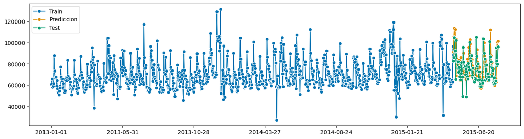

```python
fig, ax = plot_series(ts_train, ets_pred, ts_test, labels=["Train", "Prediccion", "Test"])

RMSE = MeanSquaredError(square_root=True)
MAPE = MeanAbsolutePercentageError(symmetric=False)

def ForecastPerformance(original,forecast):
    print(f'RMSE: {round(RMSE(original, forecast),2)}')
    print(f'MAPE: {round(MAPE(original, forecast)*100,2)}%')

print(ForecastPerformance(ts_test, ets_pred))
```

El resultado que he obtenido es un error porcentual absoluto medio del 12.66%. Voy a intentar mejorar el modelo mediante una cross validation, para obtener los mejores parámetros.

#### Cross validation.

```python
# Inputs: transformaciones y modelos
pipe = TransformedTargetForecaster(steps=[
    ("forecaster", NaiveForecaster())])
# Defenir el CV
cv = ExpandingWindowSplitter(
    initial_window=60,
     step_length=1,
     start_with_window=True,
     fh=fh_test)
# definir los modelos y los parametros (GRID)
gscv = ForecastingGridSearchCV(
     forecaster=pipe,
    param_grid=[{
         "forecaster": [NaiveForecaster(sp=365)],
         "forecaster__strategy": ["drift", "last", "mean"],
     },
     {
          "forecaster": [ExponentialSmoothing(sp=365)],
          "forecaster__trend": ["add", "mul"],
          "forecaster__damped_trend": [True,False],
          "forecaster__seasonal": ["add", "mul"],
    },
     ],
     cv=cv,
     verbose=1,
     n_jobs=-1)
```

```python
# Estimo todos los modelos por CV
gscv.fit(ts_train)

#Resultados
gscv.cv_results_
```

```
Fitting 693 folds for each of 11 candidates, totalling 7623 fits
```

|  | mean_test_MeanAbsolutePercentageError | mean_fit_time | mean_pred_time | params | rank_test_MeanAbsolutePercentageError |
| --- | --- | --- | --- | --- | --- |
| 0 | 2.210650e-01 | 0.225975 | 0.051017 | {'forecaster': NaiveForecaster(sp=365, strateg... | 10.0 |
| 1 | 1.504418e-01 | 0.225235 | 0.048352 | {'forecaster': NaiveForecaster(sp=365), 'forec... | 9.0 |
| 2 | 1.487885e-01 | 0.225205 | 0.049062 | {'forecaster': NaiveForecaster(sp=365, strateg... | 7.0 |
| 3 | 1.398202e-01 | 1.341733 | 0.077463 | {'forecaster': ExponentialSmoothing(damped_tre... | 3.0 |
| 4 | 4.394080e+193 | 3.209947 | 0.073871 | {'forecaster': ExponentialSmoothing(damped_tre... | 11.0 |
| 5 | 1.431525e-01 | 2.552897 | 0.071279 | {'forecaster': ExponentialSmoothing(damped_tre... | 4.0 |
| 6 | 1.500266e-01 | 4.911609 | 0.073231 | {'forecaster': ExponentialSmoothing(damped_tre... | 8.0 |
| 7 | 1.382487e-01 | 1.345927 | 0.074340 | {'forecaster': ExponentialSmoothing(seasonal='... | 1.0 |
| 8 | 1.382858e-01 | 0.809605 | 0.030869 | {'forecaster': ExponentialSmoothing(seasonal='... | 2.0 |
| 9 | 1.457417e-01 | 1.423857 | 0.027497 | {'forecaster': ExponentialSmoothing(seasonal='... | 6.0 |
| 10 | 1.433236e-01 | 1.339820 | 0.026167 | {'forecaster': ExponentialSmoothing(seasonal='... | 5.0 |

```python
# El mejor modelo.
print(gscv.best_forecaster_)

# El performance del mejor modelo
print(gscv.best_score_)
```

```
TransformedTargetForecaster(steps=[('forecaster',
                                    ExponentialSmoothing(seasonal='add', sp=365,
                                                         trend='add'))])
0.13824870255799074
```

```python
# Predicción
ets_cv_pred = gscv.predict(fh=fh_test)
ets_cv_pred.head()
```

|  | Sales |
| --- | --- |
| 2015-04-28 | 92463.547943 |
| 2015-04-29 | 89336.881425 |
| 2015-04-30 | 104286.190055 |
| 2015-05-01 | 92884.711171 |
| 2015-05-02 | 108063.031317 |

```
RMSE: 13680.41
MAPE: 12.9%
None
```

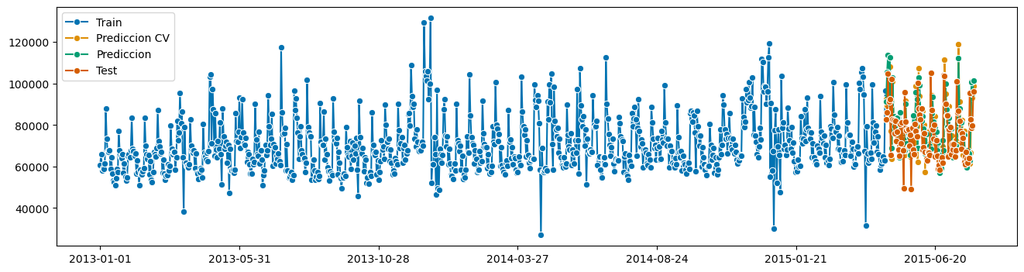

```python
fig, ax = plot_series(ts_train, ets_cv_pred, ets_pred, ts_test, labels=["Train", "Prediccion CV", "Prediccion", "Test"])

print(ForecastPerformance(ts_test, ets_cv_pred))
```

A pesar de haber entrenado distintos modelos, con varios parámetros, el MAPE más bajo ha sido un 13.82%, que tras aplicarlo a la predicción ha disminuido a un 12.9%. El modelo AutoETS devolvía un MAPE algo más bajo.

## 3. Modelo ARIMA.

```python
# Realizo la transformación logaritmica.
transformer = LogTransformer()
log_sales= transformer.fit_transform(sales_sk)
log_sales.tail()
```

| Date | Sales |
| --- | --- |
| 2015-07-27 | 11.465855 |
| 2015-07-28 | 11.321547 |
| 2015-07-29 | 11.274605 |
| 2015-07-30 | 11.284895 |
| 2015-07-31 | 11.472916 |

```python
# Divido en train y test
log_ts_train, log_ts_test = temporal_train_test_split(y = log_sales, test_size=0.1)

# Definimos el modelo
arima_model = StatsForecastAutoARIMA(sp=365)

# estimacion
arima_model.fit(log_ts_train)
```

```
StatsForecastAutoARIMA(sp=365)
```

```python
# Predicción
fh_test=np.arange(1,len(ts_test)+1)
log_arima_pred = arima_model.predict(fh=fh_test)

# Prediccion niveles
arima_pred=np.exp(log_arima_pred)
arima_pred.head()
```

|  | Sales |
| --- | --- |
| 2015-04-28 | 91085.779465 |
| 2015-04-29 | 88657.850691 |
| 2015-04-30 | 108005.837428 |
| 2015-05-01 | 96727.057817 |
| 2015-05-02 | 107352.209749 |

```
RMSE: 13529.94
MAPE: 12.45%
None
```

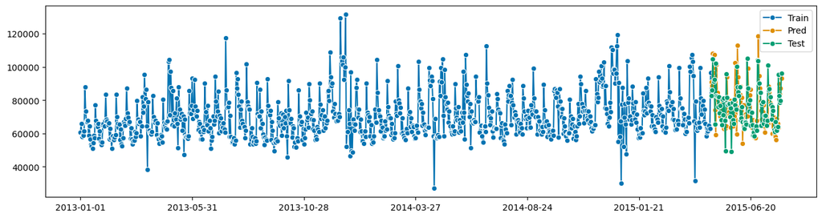

```python
fig, ax = plot_series(ts_train, arima_pred, ts_test, labels=["Train", "Pred", "Test"])

# Calcular Performance
print(ForecastPerformance(ts_test, arima_pred))
```

El MAPE que devuelve el modelo ARIMA es del 12.45%, es el más bajo obtenido hasta ahora.

## 4. Modelo Theta.

```python
# definimos el modelo
theta_model = ThetaForecaster(sp=365)
# estimacion
theta_model.fit(ts_train)
```

```
ThetaForecaster(sp=365)
```

```python
theta_model.get_fitted_params()
```

```
{'initial_level': 69362.8735809062, 'smoothing_level': 0.026572446965684775}
```

```python
# Predicción
fh_test=np.arange(1,len(ts_test)+1)
theta_pred = theta_model.predict(fh=fh_test)
theta_pred
```

|  | Sales |
| --- | --- |
| 2015-04-28 | 100077.584573 |
| 2015-04-29 | 90680.786652 |
| 2015-04-30 | 109219.507781 |
| 2015-05-01 | 99988.827192 |
| 2015-05-02 | 115003.374356 |
| ... | ... |
| 2015-07-27 | 63554.031391 |
| 2015-07-28 | 78534.864831 |
| 2015-07-29 | 98570.222901 |
| 2015-07-30 | 94989.521046 |
| 2015-07-31 | 101180.448321 |

95 rows × 1 columns

```
RMSE: 14657.5
MAPE: 14.59%
```

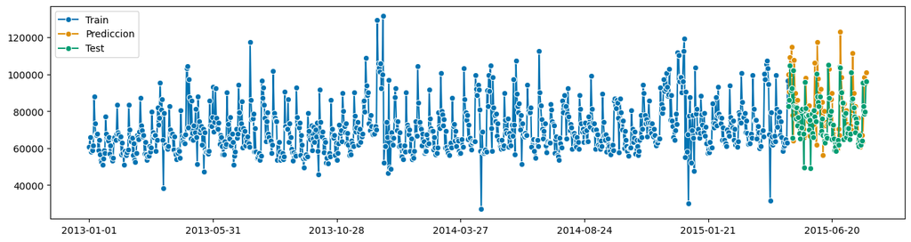

```python
fig, ax = plot_series(ts_train, theta_pred, ts_test, labels=["Train", "Prediccion", "Test"])

# Calcular Performance
ForecastPerformance(ts_test, theta_pred)
```

El modelo THETA ha resultado en un MAPE del 14.59%, lo que quiere decir que tiene un error superior a los modelos anteriormente calculados.

## 5. Modelo Prophet.

```python
# Me quedo solo con las columnas Store, Date y Sales.
y = sales_df2[['Store', 'Date', 'Sales']]

# Agrupo los datos por fecha y calculo las ventas totales.
y = y.pivot(index='Date', columns='Store')['Sales']
y = pd.DataFrame(y.sum(axis=1))

# Cambio el nombre de las columnas para ajustarlas al modelo.
y = y.reset_index(drop=False)
y.columns = ['ds', 'y']

y.head()
```

|  | ds | y |
| --- | --- | --- |
| 0 | 2013-01-01 | 0.0 |
| 1 | 2013-01-02 | 61926.0 |
| 2 | 2013-01-03 | 53588.0 |
| 3 | 2013-01-04 | 56578.0 |
| 4 | 2013-01-05 | 54938.0 |

```python
# Divido en train y test
train = y.iloc[:847,:]
test = y.iloc[847:,:]

# Compruebo el tamaño.
print("Train:", train.shape)
print("Test:", test.shape)
```

```
Train: (847, 2)
Test: (95, 2)
```

```python
# Modelo con añadiendo estacionalidad mensual
m = Prophet()
m.add_seasonality(name='monthly', period=30.5, fourier_order=5)
m.fit(train)

# Prediccion del modelo
future = m.make_future_dataframe(periods=len(test))
forecast = m.predict(future)

#Evaluación del modelo
print(r2_score(list(test['y']), list(forecast.loc[847:,'yhat'] )))
```

[output not shown]

```
0.6421283128466749
```

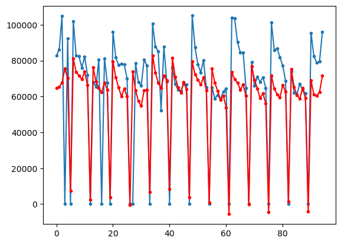

```python
# Grafico del modelo
plt.plot(list(test['y']),'.-')
plt.plot(list(forecast.loc[847:,'yhat']),'r.-')
plt.show()
```

```python
# Grafico de las predicciones.
fig1 = m.plot(forecast)
plt.show()
```

[output not shown]

En este primer intento con el modelo PROPHET he obtenido un r2 del 0.6421. Esta métrica es mejor cuánto más se acerque al valor 1, por lo que se puede ver que no es un buen modelo. A continuación voy a añadir los festivos para comprobar si mejora.

#### Añadiendo festivos.

En este apartado voy a incluir los festivos al modelo para que los tenga en cuenta. Lo que voy a hacer es además de la columna con los festivos (StateHoliday), **voy a marcar como festivos también los domingos, ya que esos días las tiendas están cerradas.**

```python
# Del data frame original cojo las columnas necesarias para establecer los festivos.
holidays = sales_df2[['Store', 'DayOfWeek', 'Date', 'StateHoliday']]

# Los días de la semana que sean 7 (domingo) que se establezca un 1 en la columna de holidays.
holidays['StateHoliday'] = np.where(holidays['DayOfWeek'] == 7, 1, holidays['StateHoliday'])

# La columna de holidays tiene valores a, b o c dependiendo del tipo de festivo que es, cambio esos valores por un 1.
holidays['StateHoliday'] = np.where(holidays['StateHoliday'] == 'a', 1, holidays['StateHoliday'])
holidays['StateHoliday'] = np.where(holidays['StateHoliday'] == 'b', 1, holidays['StateHoliday'])
holidays['StateHoliday'] = np.where(holidays['StateHoliday'] == 'c', 1, holidays['StateHoliday'])

# Agrupo los datos por fecha, quedandome con los festivos de cada dia.
holidays = holidays.groupby('Date')['StateHoliday'].last().to_frame().reset_index()

holidays.head()
```

|  | Date | StateHoliday |
| --- | --- | --- |
| 0 | 2013-01-01 | 1 |
| 1 | 2013-01-02 | 0 |
| 2 | 2013-01-03 | 0 |
| 3 | 2013-01-04 | 0 |
| 4 | 2013-01-05 | 0 |

```python
# Filtro para quedarme solo con los dias que son festivo
holidays = holidays[holidays['StateHoliday'] == 1]

# Elimino la columna de StateHoliday
holidays = holidays.drop(['StateHoliday'], axis=1)

#Creo otra columna que añada el valor 'holiday' a todas las filas, ya que ahora solo tengo los dias festivos
holidays['holiday'] = 'holiday'

#Cambio los nombres de las columnas
holidays.columns = ['ds', 'holiday']

holidays.head()
```

|  | ds | holiday |
| --- | --- | --- |
| 0 | 2013-01-01 | holiday |
| 5 | 2013-01-06 | holiday |
| 12 | 2013-01-13 | holiday |
| 19 | 2013-01-20 | holiday |
| 26 | 2013-01-27 | holiday |

```python
# Modelo.
m3 = Prophet(holidays=holidays)
m3.fit(train)

# Predicción del modelo.
future3 = m3.make_future_dataframe(periods=len(test))
forecast3 = m3.predict(future)

# Evaluación del modelo.
print(r2_score(list(test['y']), list(forecast3.loc[847:,'yhat'] )))
```

[output not shown]

```
0.8541174907722057
```

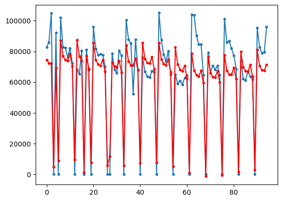

```python
# Grafico del modelo.
plt.plot(list(test['y']),'.-')
plt.plot(list(forecast3.loc[847:,'yhat']),'r.-')
plt.show()
```

```python
# Grafico de las predicciones.
fig1 = m3.plot(forecast)
plt.show()
```

[output not shown]

El modelo ha mejorado considerablemente, el r2 ha pasado a ser del 0.8541, lo que indica que se ajusta bastante bien a los datos. A continuación voy a incluir los clientes.

#### Añadiendo clientes.

```python
# Del data frame original cojo las columnas necesarias para establecer los clientes.
X_customers = sales_df2[['Store', 'Date', 'Customers']]

# Agrupo por fechas para calcular los clientes totales.
X_customers = pd.DataFrame(X_customers.groupby('Date')['Customers'].sum())
X_customers = X_customers.reset_index(drop = False)

# Guardo en otra variable el train que he usado antes para concatenarlo con la nueva columna de clientes
train4 = train.copy()
train4 = train4.merge(X_customers, left_on = 'ds', right_on = 'Date', how = 'left')[['ds', 'y', 'Customers']].fillna(0)

train4.head()
```

|  | ds | y | Customers |
| --- | --- | --- | --- |
| 0 | 2013-01-01 | 0.0 | 0 |
| 1 | 2013-01-02 | 61926.0 | 7490 |
| 2 | 2013-01-03 | 53588.0 | 6650 |
| 3 | 2013-01-04 | 56578.0 | 6784 |
| 4 | 2013-01-05 | 54938.0 | 6747 |

```python
# Modelo.
m4 = Prophet()
m4.add_regressor('Customers')
m4.fit(train4)

# Predicciones del modelo.
future4 = m4.make_future_dataframe(periods=len(test))
future4 = future4.merge(X_customers, left_on = 'ds', right_on = 'Date', how = 'left')[['ds', 'Customers']].fillna(0)
forecast4 = m4.predict(future4)

# Evaluación del modelo.
print(r2_score(list(test['y']), list(forecast4.loc[847:,'yhat'] )))
```

[output not shown]

```
0.9789844371908252
```

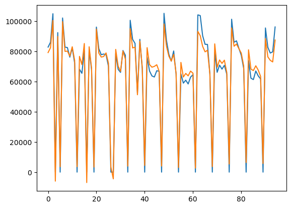

```python
# Grafico del modelo.
plt.plot(list(test['y']))
plt.plot(list(forecast4.loc[847:,'yhat'] ))
```

```python
# Grafico de las predicciones.
fig1 = m4.plot(forecast)
plt.show()
```

[output not shown]

El r2 ha vuelto a aumentar (0.9789), siendo mejor que con los festivos. Ya que he comprobado que con ambos mejora, voy a incluir los dos en el modelo para intentar mejorar algo más la métrica.

#### Añadiendo festivos y clientes.

```python
# Modelo.
m5 = Prophet(holidays = holidays)
m5.add_regressor('Customers')
m5.fit(train4)

# Predicciones del modelo.
future5 = m5.make_future_dataframe(periods=len(test))
future5 = future5.merge(X_customers, left_on = 'ds', right_on = 'Date', how = 'left')[['ds', 'Customers']].fillna(0)
forecast5 = m5.predict(future5)

# Evaluación del modelo.
print(r2_score(list(test['y']), list(forecast5.loc[847:,'yhat'] )))
```

[output not shown]

```
0.9877496175733107
```

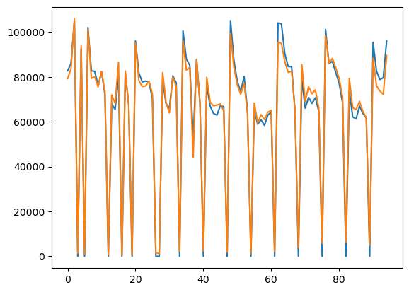

```python
# Grafico del modelo.
plt.plot(list(test['y']))
plt.plot(list(forecast5.loc[847:,'yhat'] ))
```

```python
# Grafico de las predicciones.
fig1 = m5.plot(forecast)
plt.show()
```

[output not shown]

Incluyendo tanto las vacaciones como los clientes en el modelo, el ajuste mejora ligeramente, el r2 obtenido es del 0.9877.

## 6. Predicciones.

```python
# Creo el df a usar, que ahora será el data set completo, con los 942 datos.
y2 = y.copy()
y2 = y2.merge(X_customers, left_on = 'ds', right_on = 'Date', how = 'left')[['ds', 'y', 'Customers']].fillna(0)

# Longitud de la prediccion
pred = np.arange(1, 42)

y2.head()
```

|  | ds | y | Customers |
| --- | --- | --- | --- |
| 0 | 2013-01-01 | 0.0 | 0 |
| 1 | 2013-01-02 | 61926.0 | 7490 |
| 2 | 2013-01-03 | 53588.0 | 6650 |
| 3 | 2013-01-04 | 56578.0 | 6784 |
| 4 | 2013-01-05 | 54938.0 | 6747 |

```python
# Modelo.
m_final = Prophet()
#m_final.add_regressor('Customers')
m_final.fit(y)

# Predicciones del modelo.
future_final = m_final.make_future_dataframe(periods=len(pred))
future_final = future_final.merge(X_customers, left_on = 'ds', right_on = 'Date', how = 'left')[['ds', 'Customers']].fillna(0)
forecast_final = m_final.predict(future_final)
```

[output not shown]

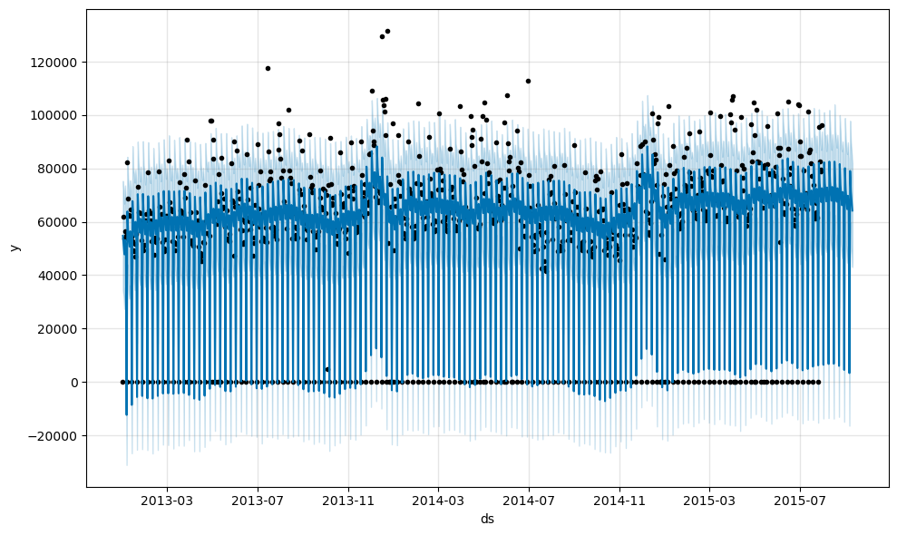

```python
# Grafico de las predicciones.
fig1 = m_final.plot(forecast_final)
plt.show()
```

Las predicciones que me ha devuelto el modelo son las que aparecen aquí. Lo que voy a hacer es sustituir el valor de los días que son domingo por 0, dado que estos días se ha comprobado que todas las tiendas están cerradas.

```python
# Fechas
fechas = pd.date_range(start='2015-08-01', end='2015-09-10', freq='D')

# Predicciones
valores = forecast_final.loc[942:,'yhat'].values

# Df con las predicciones
pred = pd.DataFrame(valores, index=fechas).rename_axis("date").reset_index()
pred.columns = ['Date', 'Sales']

# Añado una columna para ver qué dias son domingo
pred['dias'] = pred['Date'].dt.weekday

# Donde sea domingo, que ponga 0 en las ventas
pred['Sales'] = np.where(pred['dias'] == 6, 0, pred['Sales'])

#Elimino esa columna.
pred = pred.drop(['dias'], axis=1)

pred
```

|  | Date | Sales |
| --- | --- | --- |
| 0 | 2015-08-01 | 68114.516602 |
| 1 | 2015-08-02 | 0.000000 |
| 2 | 2015-08-03 | 82273.531836 |
| 3 | 2015-08-04 | 74655.519001 |
| 4 | 2015-08-05 | 71026.174749 |
| 5 | 2015-08-06 | 67640.352486 |
| 6 | 2015-08-07 | 72866.551624 |
| 7 | 2015-08-08 | 68403.582726 |
| 8 | 2015-08-09 | 0.000000 |
| 9 | 2015-08-10 | 82581.679496 |
| 10 | 2015-08-11 | 74959.834200 |
| 11 | 2015-08-12 | 71314.713154 |
| 12 | 2015-08-13 | 67899.370873 |
| 13 | 2015-08-14 | 73080.988311 |
| 14 | 2015-08-15 | 68557.604340 |
| 15 | 2015-08-16 | 0.000000 |
| 16 | 2015-08-17 | 82567.280832 |
| 17 | 2015-08-18 | 74838.941141 |
| 18 | 2015-08-19 | 71074.500653 |
| 19 | 2015-08-20 | 67529.256495 |
| 20 | 2015-08-21 | 72573.139089 |
| 21 | 2015-08-22 | 67907.363979 |
| 22 | 2015-08-23 | 0.000000 |
| 23 | 2015-08-24 | 81632.541203 |
| 24 | 2015-08-25 | 73769.652657 |
| 25 | 2015-08-26 | 69880.879917 |
| 26 | 2015-08-27 | 66225.173764 |
| 27 | 2015-08-28 | 71175.840346 |
| 28 | 2015-08-29 | 66437.073840 |
| 29 | 2015-08-30 | 0.000000 |
| 30 | 2015-08-31 | 80086.233805 |
| 31 | 2015-09-01 | 72223.388517 |
| 32 | 2015-09-02 | 68360.889045 |
| 33 | 2015-09-03 | 64757.383118 |
| 34 | 2015-09-04 | 69785.098065 |
| 35 | 2015-09-05 | 65146.388986 |
| 36 | 2015-09-06 | 0.000000 |
| 37 | 2015-09-07 | 79053.799302 |
| 38 | 2015-09-08 | 71342.148544 |
| 39 | 2015-09-09 | 67640.048974 |
| 40 | 2015-09-10 | 64201.562860 |

## 7. Exportación de los datos.

Por último, exporto las predicciones en un csv. Se encontrará en la carpeta predicciones de este trabajo.

```python
# Guardo en la variable unicamente la columna de ventas.
pred_val = pred['Sales']

# Exporto a csv, estableciendo que no se guarde ni el índice, ni la cabecera, ya que solo quiero las predicciones.
pred_val.to_csv('../predicciones/pred_diarias.csv', index=False, header=False)
```